# R01AI128765: QC report (summaryList)

Ncite Da Camara

02/05/2022

# Date

Date: Tue Nov 28 11:49:18 2023

# Run time

Time difference of 52.1 secs

Elapse time. The demoLuminexPipline took 52.1 secs to run.

# Expected vs Observed

**Kits**

There were 7 kits in this experiment.

This table lists the kit names provided and the kit names observed in the data files. Please check for discrepancies.

In most cases, discrepancies are as a result of incorrectly typed file name. For example, leaving out the letter “K” at the end of the kit name “HCYTOMAG60” that should be “HCYTOMAG60K” or not providing the underscore between kit name and additional information, i.e., “HCYTOMAG60K_RANTES” entered as “HCYTOMAG60KRANTES”.

Kits expected vs observed.

| kits_provided | kits_in_filenames |
| --- | --- |
| HCCBP2MAG58K | HCCBP2MAG58K |
| HCVD2MAG67K | HCVD2MAG67K |
| HCVD3MAG67K | HCVD3MAG67K |
| HNDG1MAG36K | HNDG1MAG36K |
| R&D22plex | R&D22plex |
| R&D4plex | R&D4plex |
| R&D5plex | R&D5plex |

**Files**

The table is used to check that the expected number of folders and files is received from the data owner and loaded.

The observed number of folders and files is what is in the input data folder. The dta_files variable is derived from the file names after the raw Luminex data were imported. Please check for discrepancies.

Compare the pre-processed QC Luminex data set to the expected meta dataset.

| exp_folders | exp_nr_of_files | exp_nr_of_plates | obs_folders | obs_nr_of_files | obs_nr_of_plates | identical_folders | identical_nr_of_files | identical_nr_of_plates |
| --- | --- | --- | --- | --- | --- | --- | --- | --- |
| HCCBP2MAG58K | 8 | 8 | HCCBP2MAG58K | 8 | 8 | TRUE | TRUE | TRUE |
| HCVD2MAG67K | 8 | 8 | HCVD2MAG67K | 8 | 8 | TRUE | TRUE | TRUE |
| HCVD3MAG67K | 8 | 8 | HCVD3MAG67K | 8 | 8 | TRUE | TRUE | TRUE |
| HNDG1MAG36K | 8 | 8 | HNDG1MAG36K | 8 | 8 | TRUE | TRUE | TRUE |
| R&D22plex | 8 | 8 | R&D22plex | 8 | 8 | TRUE | TRUE | TRUE |
| R&D4plex | 8 | 8 | R&D4plex | 8 | 8 | TRUE | TRUE | TRUE |
| R&D5plex | 8 | 8 | R&D5plex | 8 | 8 | TRUE | TRUE | TRUE |
| Total | 56 | 56 | — | 56 | 56 | — | — | — |

**New analyte names**

New analyte names that are present in the raw Luminex data and not present in the analyte reference table (i.e., “analyte_synonyms.csv”). These new analyte names should be added to the analyte reference table (i.e., “analyte_synonyms.csv”) after they have been assessed and approved by the Bioinformatics group investigators.

```
## [1] "No new analyte names identified in the raw Luminex data that is not in the analyte reference table."
```

**Description**

Total unique descriptions (i.e., specimen ID’s) in the raw Luminex data.

| total_description |
| --- |
| 582 |

Unique descriptions (i.e., specimen ID’s) in the raw Luminex data.

| unique_description |
| --- |
| qc1 |
| qc2 |
| iqc |
| 12359 |
| 40632 |
| 12337 |
| klf-500077/500077 |
| pg0564 |
| 12939 |
| klf-94018 |
| 40219 |
| klf-500009/500009 |
| klf-500109 |
| klf-96951/100430 |
| 12497 |
| klf-96576/100410 |
| klf-m-500544/500544 |
| klf-500342/500342 |
| 10050 |
| 12226 |
| 12807 |
| 12455 |
| 40583 |
| 10021 |
| klf-3-104652/800958 |
| 40441 |
| 12282 |
| klf-93994 |
| 40179 |
| 12214 |

[output cut: 551 more lines]

**Experiment design**

**Total number of unknown specimens (i.e., X) per analyte, per kit and per plate**

The table shows the total number of unknown specimens (i.e., X) per analyte, per kit and per plate number.

The table also used to visualise missing unknown specimens per analyte, per kit and per plate.

On average we expect 74-76 number of measurements for the unknown specimens [excluding the Blanks (B), Controls (IQC1, IQC2, and IQC3) and Standards (S)]. If you see any entries differing from this, please discuss with the data analyst.

Total number of unknown specimen per analyte, per kit and per plate.

| analyte_new | kitname | 1 | 2 | 3 | 4 | 5 | 6 | 7 | 8 | is_na |
| --- | --- | --- | --- | --- | --- | --- | --- | --- | --- | --- |
| a2m | HCVD3MAG67K | 39 | 50 | 43 | 49 | 47 | 52 | 50 | 45 | FALSE |
| apcs | HCVD3MAG67K | 39 | 50 | 43 | 49 | 47 | 52 | 50 | 45 | FALSE |
| apoa1 | HNDG1MAG36K | 39 | 50 | 43 | 49 | 47 | 52 | 50 | 45 | FALSE |
| ccl1 | R&D22plex | 39 | 50 | 43 | 49 | 47 | 52 | 50 | 45 | FALSE |
| ccl14 | R&D4plex | 39 | 50 | 43 | 49 | 47 | 52 | 50 | 45 | FALSE |
| ccl18 | R&D4plex | 39 | 50 | 43 | 49 | 47 | 52 | 50 | 45 | FALSE |
| ccl22 | R&D22plex | 39 | 50 | 43 | 49 | 47 | 52 | 50 | 45 | FALSE |
| ccl3 | R&D22plex | 39 | 50 | 43 | 49 | NA | NA | 50 | 45 | FALSE |
| ccl3 | R&D5plex | NA | NA | NA | NA | 47 | 52 | NA | NA | FALSE |
| ccl4 | R&D22plex | 39 | 50 | 43 | 49 | 47 | 52 | 50 | 45 | FALSE |
| cd40 | R&D22plex | 39 | 50 | 43 | 49 | NA | NA | 50 | 45 | FALSE |
| cd40lg | R&D22plex | NA | NA | NA | NA | 47 | 52 | NA | NA | FALSE |
| cfh | HNDG1MAG36K | 39 | 50 | 43 | 49 | 47 | 52 | 50 | 45 | FALSE |
| crp | HCVD3MAG67K | 39 | 50 | 43 | 49 | 47 | 52 | 50 | 45 | FALSE |
| cxcl10 | R&D22plex | 39 | 50 | 43 | 49 | 47 | 52 | 50 | 45 | FALSE |
| cxcl12 | R&D22plex | 39 | 50 | 43 | 49 | 47 | 52 | 50 | 45 | FALSE |
| cxcl5 | R&D22plex | 39 | 50 | 43 | 49 | 47 | 52 | 50 | 45 | FALSE |
| cxcl9 | R&D5plex | 39 | 50 | 43 | 49 | 47 | 52 | 50 | 45 | FALSE |
| ecm1 | HCCBP2MAG58K | 39 | 50 | 43 | 49 | 47 | 52 | 50 | 45 | FALSE |
| fgf2 | R&D22plex | 39 | 50 | 43 | 49 | 47 | 52 | 50 | 45 | FALSE |
| fibrinogen | HCVD3MAG67K | 39 | 50 | 43 | 49 | 47 | 52 | 50 | 45 | FALSE |
| ftl | R&D4plex | 39 | 50 | 43 | 49 | 47 | 52 | 50 | 45 | FALSE |
| gdf15 | R&D22plex | 39 | 50 | 43 | 49 | 47 | 52 | 50 | 45 | FALSE |
| hp | HCVD3MAG67K | 39 | 50 | 43 | 49 | 47 | 52 | 50 | 45 | FALSE |
| ifng | R&D22plex | 39 | 50 | 43 | 49 | 47 | 52 | 50 | 45 | FALSE |
| il10 | R&D22plex | 39 | 50 | 43 | 49 | 47 | 52 | 50 | 45 | FALSE |
| il12a | R&D22plex | 39 | 50 | 43 | 49 | 47 | 52 | 50 | 45 | FALSE |
| il13 | R&D22plex | 39 | 50 | 43 | 49 | 47 | 52 | 50 | 45 | FALSE |
| il15 | R&D22plex | 39 | 50 | 43 | 49 | 47 | 52 | 50 | 45 | FALSE |
| il1b | R&D22plex | 39 | 50 | 43 | 49 | 47 | 52 | 50 | 45 | FALSE |
| il22 | R&D22plex | NA | NA | NA | NA | 47 | 52 | NA | NA | FALSE |
| il22 | R&D5plex | 39 | 50 | 43 | 49 | NA | NA | 50 | 45 | FALSE |
| il6 | R&D22plex | NA | NA | NA | NA | 47 | 52 | NA | NA | FALSE |
| il6r | R&D22plex | 39 | 50 | 43 | 49 | NA | NA | 50 | 45 | FALSE |
| il7 | R&D22plex | 39 | 50 | 43 | 49 | 47 | 52 | 50 | 45 | FALSE |
| lta | R&D22plex | 39 | 50 | 43 | 49 | 47 | 52 | 50 | 45 | FALSE |
| mmp1 | R&D22plex | 39 | 50 | 43 | 49 | 47 | 52 | 50 | 45 | FALSE |
| mmp9 | R&D4plex | 39 | 50 | 43 | 49 | 47 | 52 | 50 | 45 | FALSE |
| ncam1 | R&D5plex | 39 | 50 | 43 | 49 | 47 | 52 | 50 | 45 | FALSE |
| procalcitonin | R&D22plex | 39 | 50 | 43 | 49 | 47 | 52 | 50 | 45 | FALSE |
| saa1 | HCVD2MAG67K | 39 | 50 | 43 | 49 | 47 | 52 | 50 | 45 | FALSE |
| serpinc1 | HCCBP2MAG58K | 39 | 50 | 43 | 49 | 47 | 52 | 50 | 45 | FALSE |
| tgfa | R&D5plex | 39 | 50 | 43 | 49 | 47 | 52 | 50 | 45 | FALSE |
| tnf | R&D22plex | 39 | 50 | 43 | 49 | 47 | 52 | 50 | 45 | FALSE |
| vegfa | R&D5plex | 39 | 50 | 43 | 49 | 47 | 52 | 50 | 45 | FALSE |

**NB! Please check before doing analyses**

Please check the missingness in the table and if it is what you expect.

Missingness can be due to a whole plate failing laboratory QC or analyte name or kit name capture error.

**Example**

**There can be different scenarios for example:**

1. Two analytes with the same name, but different kit names, and measurements not on all the plates (Example 1).
2. The analyte name is different (i.e., spelling different), however have the same kit name, and measurements not on all the plates (Example 2). Please see example data below.
3. Manufacturer error. For example, error made by the manufacturer including the wrong analyte in the kit (e.g., “il6” and “il6r”) (Example 3).

Example1. Total number of unknown specimen per analyte, per kit and per plate.

| analyte_new | kitname | 1 | 2 | 3 | 4 | 5 | 6 | 7 | 8 |
| --- | --- | --- | --- | --- | --- | --- | --- | --- | --- |
| ccl3 | R&D5plex | NA | NA | NA | NA | 73 | 71 | NA | NA |
| ccl3 | R&D22plex | 72 | 73 | 72 | 71 | NA | NA | 73 | 73 |

Example2. Total number of unknown specimen per analyte, per kit and per plate.

| analyte_new | kitname | 1 | 2 | 3 | 4 | 5 | 6 | 7 | 8 |
| --- | --- | --- | --- | --- | --- | --- | --- | --- | --- |
| cd40 | R&D22plex | 72 | 73 | 72 | 71 | NA | NA | 73 | 73 |
| cd40lg | R&D22plex | NA | NA | NA | NA | 73 | 71 | NA | NA |

Example3. Total number of unknown specimen per analyte, per kit and per plate.

| analyte_new | kitname | 1 | 2 | 3 | 4 | 5 | 6 | 7 | 8 |
| --- | --- | --- | --- | --- | --- | --- | --- | --- | --- |
| il6 | R&D22plex | NA | NA | NA | NA | 73 | 71 | NA | NA |
| il6r | R&D22plex | 72 | 73 | 72 | 71 | NA | NA | 73 | 73 |

If you see any entries differing from this, please discuss with the data analyst.

**Total distinct analytes used in the study**

The total number of distinct analytes in the data was **43 analytes** and the total analytes used in the study is **45 analytes**.

If this is not as expected please contact the data analyst.

**Total analytes per kit**

The table shows the total number of analytes per kit in the data.

Important, the total number of analytes in the table may differ from the total number of distinct analytes in the data. A reason is that the same analyte or an analyte with the same name is present in different kits.

If this is not as expected please contact the data analyst.

Total analytes per kit.

| kitname | analytecount | is_na |
| --- | --- | --- |
| HCCBP2MAG58K | 2 | FALSE |
| HCVD2MAG67K | 1 | FALSE |
| HCVD3MAG67K | 5 | FALSE |
| HNDG1MAG36K | 2 | FALSE |
| R&D22plex | 25 | FALSE |
| R&D4plex | 4 | FALSE |
| R&D5plex | 6 | FALSE |
| Total | 45 | — |

**Total plates per kit and instrument**

See table to view the number of plates per kit and instrument (i.e., BP, MP) in the data.

If this is not as expected please contact the data analyst.

Total plates per kit and instrument.

| instrumentname | kitname | platecount | is_na |
| --- | --- | --- | --- |
| BP | HCCBP2MAG58K | 6 | FALSE |
| BP | HCVD2MAG67K | 8 | FALSE |
| BP | HCVD3MAG67K | 2 | FALSE |
| BP | HNDG1MAG36K | 8 | FALSE |
| BP | R&D22plex | 2 | FALSE |
| BP | R&D4plex | 4 | FALSE |
| BP | R&D5plex | 4 | FALSE |
| MP | HCCBP2MAG58K | 2 | FALSE |
| MP | HCVD3MAG67K | 6 | FALSE |
| MP | R&D22plex | 6 | FALSE |
| MP | R&D4plex | 4 | FALSE |
| MP | R&D5plex | 4 | FALSE |
| Total | — | 56 | — |

**Total analytes per instrument, kit and plate number**

The total number of analytes per instrument, kit and plate number in the data are shown in table.

If this is not as expected please contact the data analyst.

Total analytes per instrument, kit and plate number.

| instrumentname | kitname | 1 | 2 | 3 | 4 | 5 | 6 | 7 | 8 | is_na |
| --- | --- | --- | --- | --- | --- | --- | --- | --- | --- | --- |
| BP | HCVD2MAG67K | 1 | 1 | 1 | 1 | 1 | 1 | 1 | 1 | FALSE |
| BP | HCVD3MAG67K | 5 | 5 | NA | NA | NA | NA | NA | NA | FALSE |
| BP | HNDG1MAG36K | 2 | 2 | 2 | 2 | 2 | 2 | 2 | 2 | FALSE |
| BP | R&D5plex | 5 | 5 | 5 | 5 | NA | NA | NA | NA | FALSE |
| BP | HCCBP2MAG58K | NA | NA | 2 | 2 | 2 | 2 | 2 | 2 | FALSE |
| BP | R&D22plex | NA | NA | NA | NA | 22 | 22 | NA | NA | FALSE |
| BP | R&D4plex | NA | NA | NA | NA | 4 | 4 | 4 | 4 | FALSE |
| MP | HCCBP2MAG58K | 2 | 2 | NA | NA | NA | NA | NA | NA | FALSE |
| MP | R&D22plex | 22 | 22 | 22 | 22 | NA | NA | 22 | 22 | FALSE |
| MP | R&D4plex | 4 | 4 | 4 | 4 | NA | NA | NA | NA | FALSE |
| MP | HCVD3MAG67K | NA | NA | 5 | 5 | 5 | 5 | 5 | 5 | FALSE |
| MP | R&D5plex | NA | NA | NA | NA | 5 | 5 | 5 | 5 | FALSE |

**Visualise missing proportions in the data**

The table provides valuable information on the proportion of missing values according to the type of missing value [i.e., out of range (oor) less than (lt), oor greater than (gt), or true missing] per analyte in the data. The variables (i.e., columns) are labeled “prop_oorlt”, “prop_oorgt”, and “prop_true_missing”, respectively. See table.

If this is not as expected please contact the data analyst.

Additional information is also provided such as the kit name, time point, stimulation condition, and total number of unknown specimens analysed per analyte. The variables are labeled as follows: “kitname”, “analyte_new”, “timepoint”, “stimulation”, “total”, respectively. See table.

Visualise missing proportions in the data.

| kitname | analyte_new | timepoint | stimulation | total | prop_oorlt | prop_oorgt | prop_true_missing | is_na |
| --- | --- | --- | --- | --- | --- | --- | --- | --- |
| HCCBP2MAG58K | ecm1 | bl | unstim | 375 | 0.0080000 | 0.0000000 | 0 | FALSE |
| HCCBP2MAG58K | serpinc1 | bl | unstim | 375 | 0.0053333 | 0.0000000 | 0 | FALSE |
| HCVD2MAG67K | saa1 | bl | unstim | 375 | 0.0080000 | 0.4640000 | 0 | FALSE |
| HCVD3MAG67K | a2m | bl | unstim | 375 | 0.0053333 | 0.0000000 | 0 | FALSE |
| HCVD3MAG67K | apcs | bl | unstim | 375 | 0.0080000 | 0.0000000 | 0 | FALSE |
| HCVD3MAG67K | crp | bl | unstim | 375 | 0.0080000 | 0.0000000 | 0 | FALSE |
| HCVD3MAG67K | fibrinogen | bl | unstim | 375 | 0.0800000 | 0.0000000 | 0 | FALSE |
| HCVD3MAG67K | hp | bl | unstim | 375 | 0.0053333 | 0.2453333 | 0 | FALSE |
| HNDG1MAG36K | apoa1 | bl | unstim | 375 | 0.1280000 | 0.0000000 | 0 | FALSE |
| HNDG1MAG36K | cfh | bl | unstim | 375 | 0.1146667 | 0.0000000 | 0 | FALSE |
| R&D22plex | ccl1 | bl | unstim | 375 | 0.1226667 | 0.0000000 | 0 | FALSE |
| R&D22plex | ccl22 | bl | unstim | 375 | 0.0053333 | 0.0000000 | 0 | FALSE |
| R&D22plex | ccl3 | bl | unstim | 276 | 0.3297101 | 0.0000000 | 0 | FALSE |
| R&D22plex | ccl4 | bl | unstim | 375 | 0.1386667 | 0.0000000 | 0 | FALSE |
| R&D22plex | cd40 | bl | unstim | 276 | 0.0000000 | 0.0000000 | 0 | FALSE |
| R&D22plex | cd40lg | bl | unstim | 99 | 0.0000000 | 0.0000000 | 0 | FALSE |
| R&D22plex | cxcl10 | bl | unstim | 375 | 0.0000000 | 0.0000000 | 0 | FALSE |
| R&D22plex | cxcl12 | bl | unstim | 375 | 0.0000000 | 0.0000000 | 0 | FALSE |
| R&D22plex | cxcl5 | bl | unstim | 375 | 0.0000000 | 0.0000000 | 0 | FALSE |
| R&D22plex | fgf2 | bl | unstim | 375 | 0.0133333 | 0.0000000 | 0 | FALSE |
| R&D22plex | gdf15 | bl | unstim | 375 | 0.0053333 | 0.0000000 | 0 | FALSE |
| R&D22plex | ifng | bl | unstim | 375 | 0.2613333 | 0.0000000 | 0 | FALSE |
| R&D22plex | il10 | bl | unstim | 375 | 0.5733333 | 0.0000000 | 0 | FALSE |
| R&D22plex | il12a | bl | unstim | 375 | 0.7200000 | 0.0000000 | 0 | FALSE |
| R&D22plex | il13 | bl | unstim | 375 | 0.2693333 | 0.0000000 | 0 | FALSE |
| R&D22plex | il15 | bl | unstim | 375 | 0.6800000 | 0.0000000 | 0 | FALSE |
| R&D22plex | il1b | bl | unstim | 375 | 0.3840000 | 0.0000000 | 0 | FALSE |
| R&D22plex | il22 | bl | unstim | 99 | 0.2323232 | 0.0000000 | 0 | FALSE |
| R&D22plex | il6 | bl | unstim | 99 | 0.4141414 | 0.0000000 | 0 | FALSE |
| R&D22plex | il6r | bl | unstim | 276 | 0.0000000 | 0.0000000 | 0 | FALSE |
| R&D22plex | il7 | bl | unstim | 375 | 0.0026667 | 0.0000000 | 0 | FALSE |
| R&D22plex | lta | bl | unstim | 375 | 0.9386667 | 0.0000000 | 0 | FALSE |
| R&D22plex | mmp1 | bl | unstim | 375 | 0.0000000 | 0.0000000 | 0 | FALSE |
| R&D22plex | procalcitonin | bl | unstim | 375 | 0.0026667 | 0.0160000 | 0 | FALSE |
| R&D22plex | tnf | bl | unstim | 375 | 0.2400000 | 0.0000000 | 0 | FALSE |
| R&D4plex | ccl14 | bl | unstim | 375 | 0.0000000 | 0.0000000 | 0 | FALSE |
| R&D4plex | ccl18 | bl | unstim | 375 | 0.0000000 | 0.4053333 | 0 | FALSE |
| R&D4plex | ftl | bl | unstim | 375 | 0.0000000 | 0.1706667 | 0 | FALSE |
| R&D4plex | mmp9 | bl | unstim | 375 | 0.0000000 | 0.0000000 | 0 | FALSE |
| R&D5plex | ccl3 | bl | unstim | 99 | 0.5050505 | 0.0000000 | 0 | FALSE |
| R&D5plex | cxcl9 | bl | unstim | 375 | 0.0266667 | 0.0000000 | 0 | FALSE |
| R&D5plex | il22 | bl | unstim | 276 | 0.4782609 | 0.0000000 | 0 | FALSE |
| R&D5plex | ncam1 | bl | unstim | 375 | 0.0000000 | 0.0000000 | 0 | FALSE |
| R&D5plex | tgfa | bl | unstim | 375 | 0.3840000 | 0.0000000 | 0 | FALSE |
| R&D5plex | vegfa | bl | unstim | 375 | 0.0026667 | 0.0000000 | 0 | FALSE |

**Proportion OOR less than (<) figure**

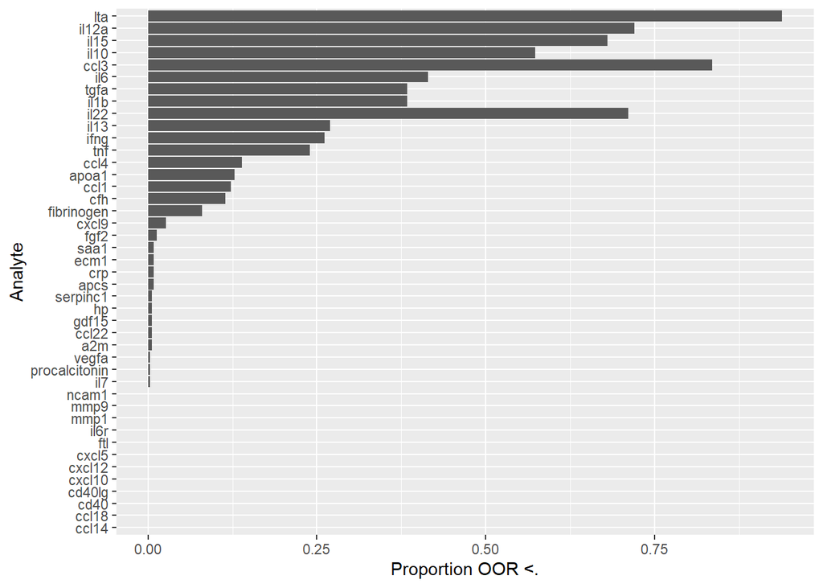

**Proportion OOR greater than (>) figure**

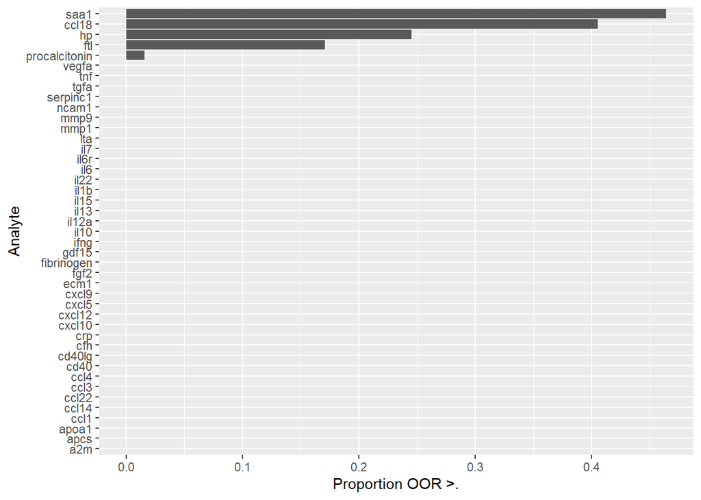

**Proportion true missingness figure**

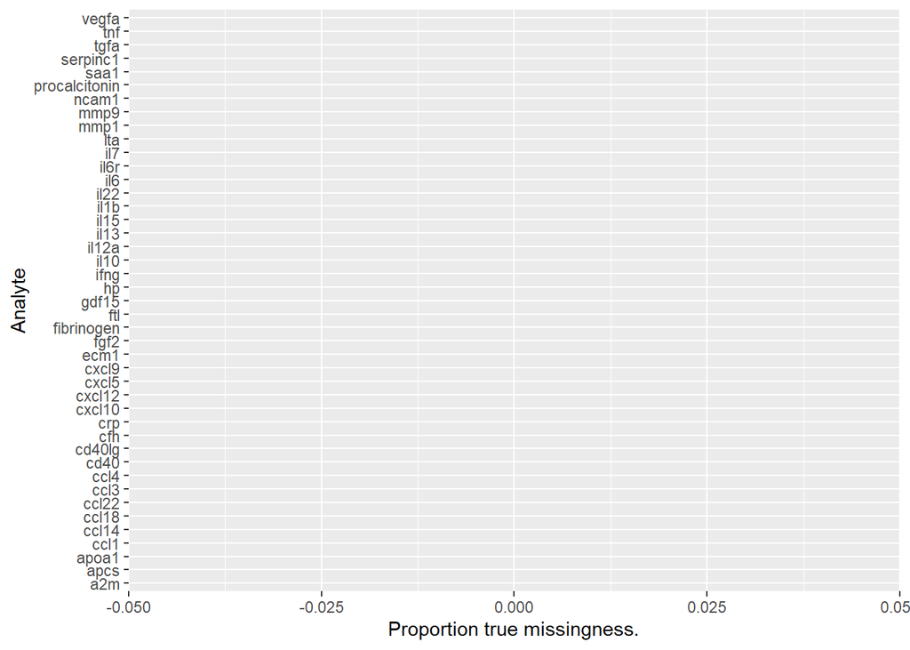

# Error log

**Instrument name errors**

Check if there are instrument name errors in the data.

If this is not as expected please contact the data analyst.

[1] “Instrument names match expected.” **Dates**

Incorrectly parsed dates in the data:

NULL If this is not as expected please contact the data analyst.